# GenoPred Report

ID: example_plink2

# Target Descriptives

- The target sample contains 12 individuals.
- The target genotype data was provided in plink2 format.
- Of the 1000 variants in the reference, 1000 were available in the target (100%).

# Ancestry

- 10 out of 12 target individuals in the sample, were assigned to a reference population with a probability >50%.
- The number of individuals assigned to each population were:

| Population | N |
| --- | --- |
| AFR | 2 |
| AMR | 0 |
| CSA | 1 |
| EAS | 2 |
| EUR | 5 |
| MID | 0 |
| Unassigned | 2 |

**Show principal component plots**

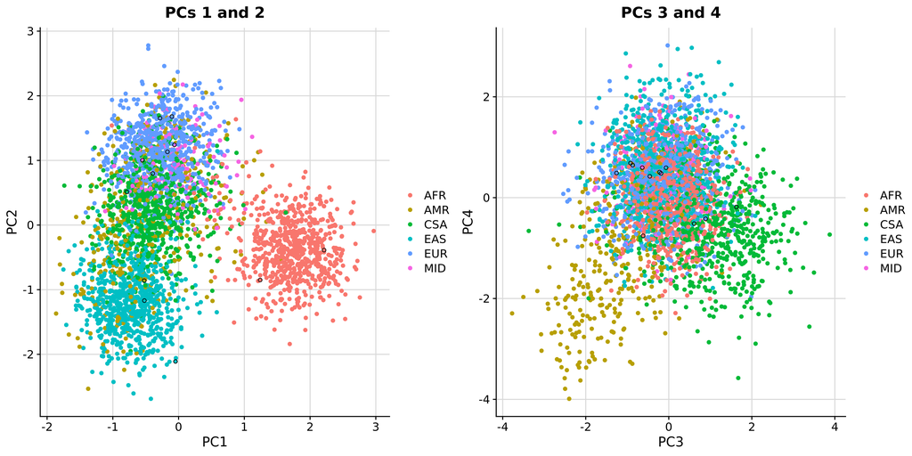

**Target Principal Component Scores Compared to Reference Populations.**

**Note.** Black circles indicate target sample individuals.

# Polygenic Scores

- 1 GWAS summary statistics were provided for polygenic scoring.
- 0 GWAS groups were specified.
- 2 PGS methods were applied, including lassosum, ptclump.
- 1 external score files were provided for polygenic scoring.

## GWAS summary statistics

| Name | Label | Population | NSNP Original | NSNP Final |
| --- | --- | --- | --- | --- |
| BODY04 | Body Mass Index | EUR | 885 | 841 |

**Show GWAS header interpretations**

**BODY04**

| Header | Interpretation |
| --- | --- |
| SNP | RSID for variant |
| A1 | Allele 1 (effect allele) |
| A2 | Allele 2 |
| P | P-value of association |
| BETA | BETA effect size |
| SE | Standard error of log(OR) or BETA |
| N | Total sample size |

**Note.** Columns that were dropped are not shown here.

## Score files

| Name | Label | NSNP Original | NSNP Final | Pass |
| --- | --- | --- | --- | --- |
| PGS002804 | Height Yengo EUR | 708 | 708 | True |

**Note.** The `Pass` column indicates whether a sufficient number of variants within the score file were present in the reference data.

## PGS correlation

This section shows the correlation between PGS in the reference sample. This is intended as a sanity check that the PGS correlations are in the expected direction, thereby confirming the GWAS alleles are being interpreted correctly.

**Show reference PGS correlation matrix**

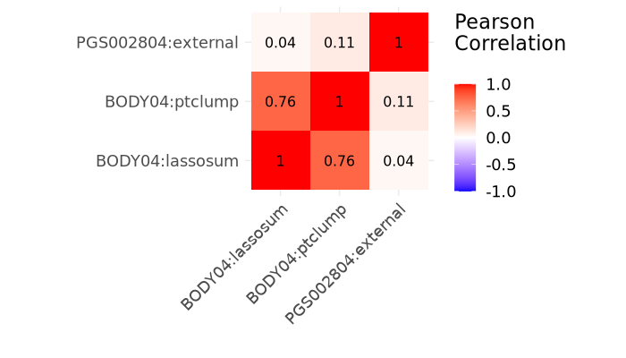

**Note.** Plot shows correlation between pseudovalidated PGS across all populations, adjusted for ancestry.

## PGS Distribution

This section shows the distribution of PGS in the target sample. PGS are shown scaled according to each ancestry-match reference population. TRANS includes PGS across all populations after continuous adjustment for ancestry.

### lassosum

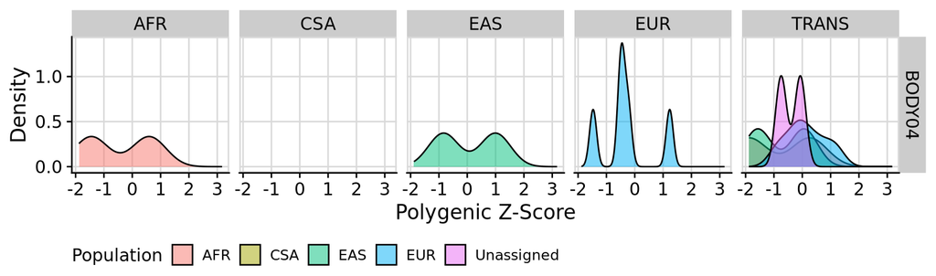

Density plot of PGS from lassosum

### ptclump

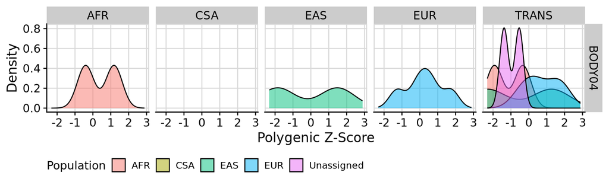

Density plot of PGS from ptclump

### external

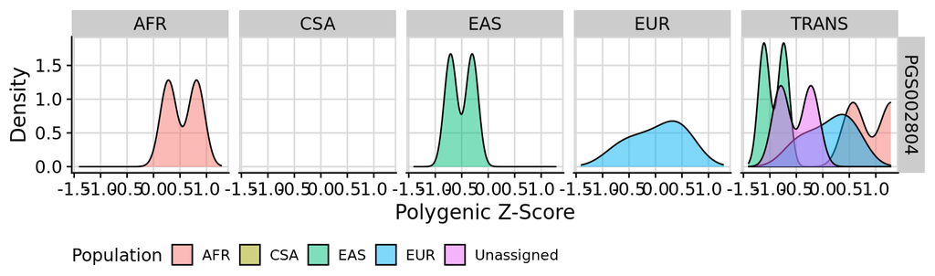

Density plot of PGS from external

**Note.** Plot shows distribution of pseudovalidated PGS.

This report was created using GenoPred (v2.2.2-312-g61d3a33).